# **OBJECTIVE :**

## >>> **Produce a Power BI report for Management team for an interactive dashboard of the whole project**

# **`Business Case & Hypothesis`**

# **`With Databricks & Azure Data Explorer & Power BI`**

[figure not shown]

# **1. CONTEXT DESCRIPTION**

# >>> **Scenario:**

## **End of October 2019 and a US company is looking for analysis on the market**

# >>> **Goal:**

## **Produce an interactive dashboard for the Management team to have in a single report answers of the questions :**

### A) How the US market evolve during the 2010s decade by sector ?

### B) What are the prediction for the next 6 month by sector ?

### C) In which sector to invest ?

### D) What is the market segmentation ?

### E) What is the consumer behaviors ?

### **Do to it, the project is split is different parts (based on the data tool usage)**

### B) Databricks using the Spark - distributed computing system - for scalability, data processing, machine learning & deep learning algorithms

### C) Azure Data Explorer (ADX) as Serving Layer which work perfectly with power bi (Kusto connector)

### D) Power BI for data visulisation

# >>> **Focus on ADX & Power BI:**

### The project detail on Databricks, Machine Learning algorithm & deep learning algorithms are available for consulation on my portfolio, 'Tech Lead' section.

### On this part, I will focus on the ADX and Power BI tools used for the project.

# **2. AZURE DATA EXPLORER**

#### **1. Data Ingestion**

##### From the local exported files, I upload into ADX

[figure not shown]

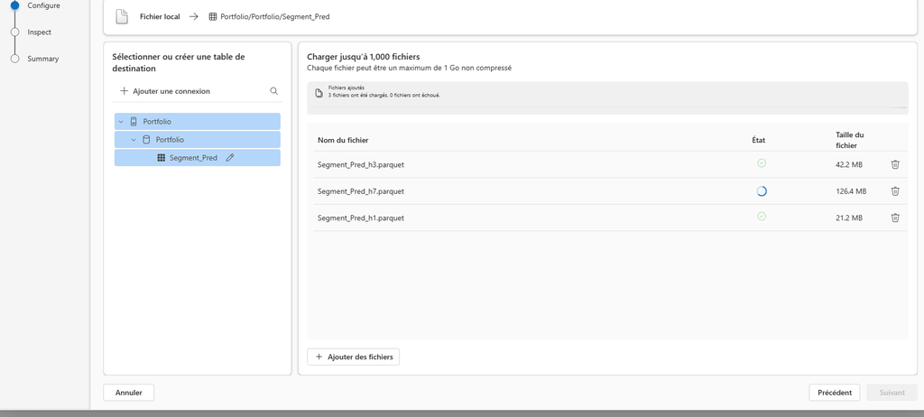

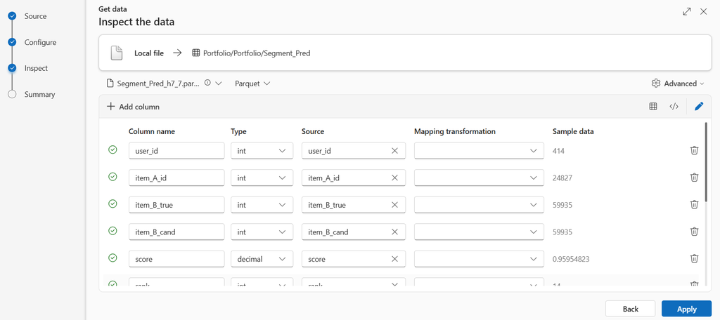

#### **2. Data Transformation**

##### For the Power BI presentation I needed date information.

I choose to create a function in Azure on transactions_data table (before connecting to Power BI).

Why this choice ? I choose to NOT touch original tables, so I could create a new one but it's much more efficient in this case due to the fact the original table is 13+ Millions rows.

Number of rows of the original table :

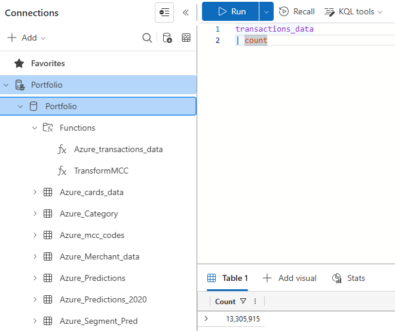

Function created :

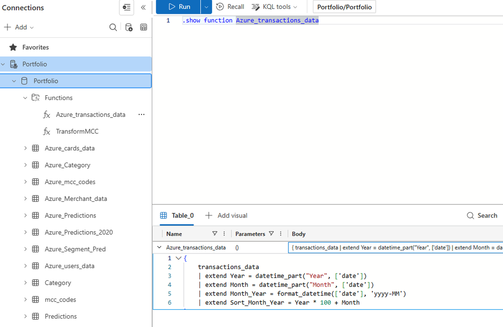

##### Then when all tables where ready, I connected to Power BI.

# **3. POWER BI**

#### **1. Data Connection**

##### I have connected each table to the Power Bi tool as below :

For the table Azure_data_cards

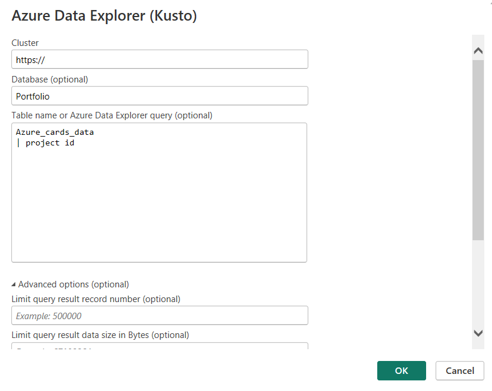

For the table Azure_transactions_data

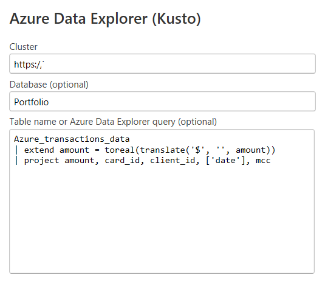

For the table Azure_Segment_Pred

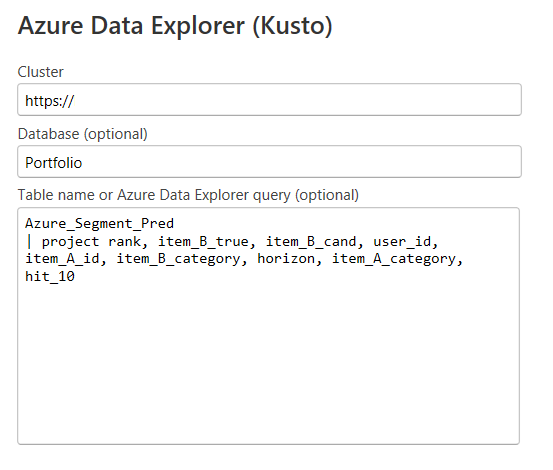

#### **2. Forecasted table**

The project aims to answer about the 6 months predictions bu sector.

This part was done using a Machine Learning model with the result of 2 tables :

> Table 1 : **Training & Test Table** (to learn the model and compare training result with the reality)

> Table 2 : **Prediction** - then when the predictde model showed proper accuracy I used it to predict the futur.

And then in Power BI, I had to **merge the both table into a unique table containing past and prediction**

Below the Query used into Power Bi to merge the tables :

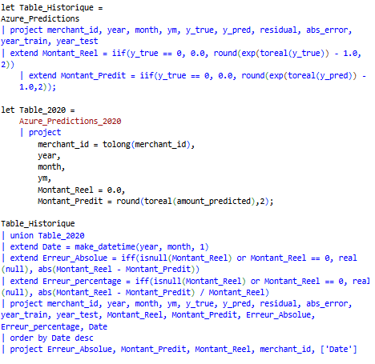

#### **3. Power BI Data Model**

Once tables were all connected to Power BI, the next step was to create the Data Model and relationship between tables.

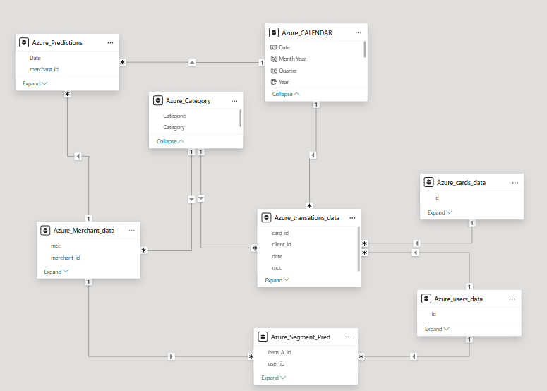

#### **4. Design and Measures creation**

After the tables were properly linked toghether, It ws the time to design the report and create the useful DAX measures for a clear insight data presentation.

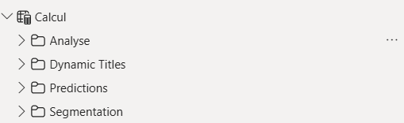

I have created some dynamic titles in order a dynamic presentation. I use these methodology to drill down the data by creating a switch button. The user can quickly switch and compare data using the same presentation.

I have created as well many other DAX formulas as for example the Trend to compare the trend of the 2 economic cyles with the below formulas:

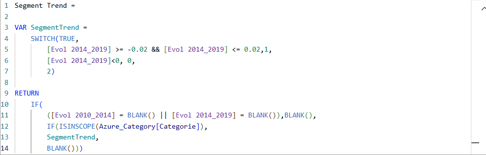

Coming back to the Forecasted table created, then i have created a DAX formulas to present the Global Budget Accuracy and the Month Budget Accuracy

**Global Budget Accuracy:**

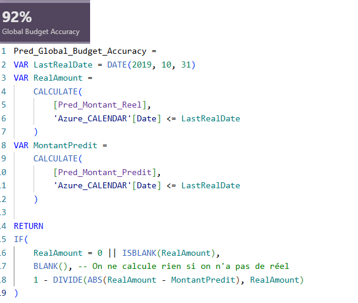

**Monthly Budget Accuracy:**

Even if the global budget accuracy shows a good result, it appears during the period a precision's volatility. That's why I have created this additionnal indicator for users to know if the prediction can be used as it is or an additionnal manual evaluation is needed.

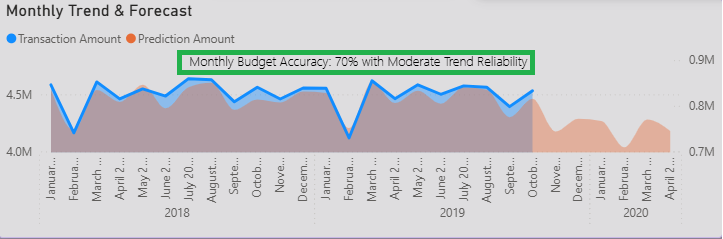

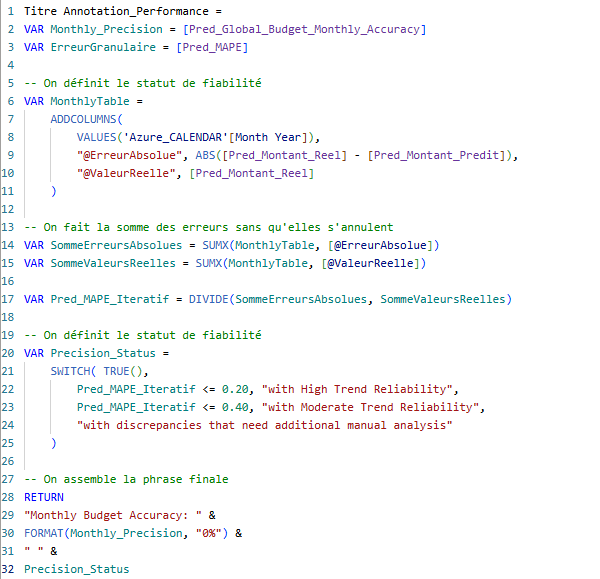

Finaly I have created the formulas for the **segmentation analysis and consumer behavior prediction** from the deep learning model.

In my portfolio the Deep Learning model is learning insights and patterns concerning the consumer's behavior. this kind of model is generally used in real life for advertising by predicting the probabilty of the next purchase. **In this example, using a professional pipeline, data can be streamed then get the real-time trend for the Marketing Direction for example.**

For example below after buying something on Utilities sector, there is 67% probabilities for the next purchase to the something on the Computer Netword or Industrial equipment and Supplies.

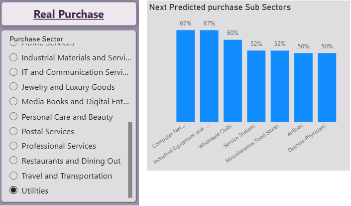

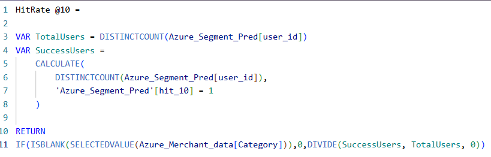

#### **5. Model Optimization**

Using Measure Killer or tabulard Editor, I verify and optimize the model performance.

Verification of the links between tables

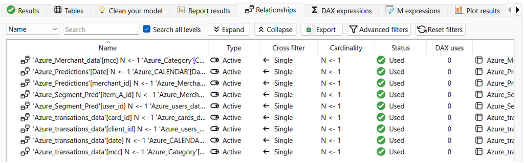

Global Verification of the mode: Potential unused tables, measures, verification of the best practises usage...

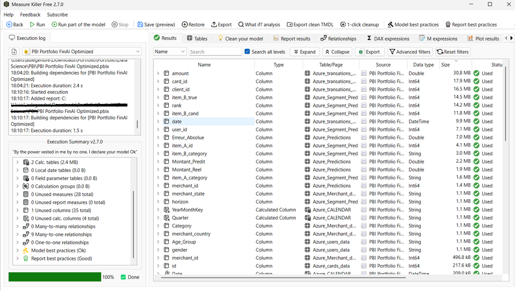

# **4. CONCLUSION**

## This Power BI reporting shows a end-to-end project from the market global analysis, to a behavioral consumer prediction by showing a market prediction for potential investments...

## The purpose of this report is:

### A) to be **interactive and streamed for fast decision making concernig consumer behavior for Marketing Department**.

### B) to be **accurate for budgeting purposes for the Finance Department.**

## **Author : Aurelien Legendre**

[figure not shown]